# The pyrho EUR map against HapMap II lifted and the pyrho median (#404)

Published

November 6, 2026

## The question

Is the published pyrho EUR map — the equal-weight mean of the five population maps — adequate for `n_loci_*`, or does another genetic map do better? #403 swept D and W on the 37 EUR Analyses it drew and found that **C1 holds everywhere, C2 at all but D 0.1 cM, and C3 nowhere**: no cM point beat the plain bp window at the same W. This repeats that sweep unchanged, on the same Analyses and the same rows, with two other maps:

- **HapMap II combined, lifted to GRCh38**, as Eagle ships it (LD-based, the comparator #62’s revision names);
- **the median of the same five pyrho maps**, the alternative to the two single-population spikes #402 found in the mean.

The question C3 asks is whether genetic distance earns its keep at all, so a map that makes C3 hold would change the epic’s decision; a map that only shifts the rates does not.

## The maps

| map | chromosomes | points | genetic length (cM) | points dropped | sha256 | source |
| --- | --- | --- | --- | --- | --- | --- |
| pyrho-mean | 22 | 3,711,299 | 2618.0 | not recorded | `146989362889…` | https://zenodo.org/records/11437540 |
| pyrho-median | 22 | 3,711,299 | 2419.9 | 0 | `ad07d38ce253…` | https://zenodo.org/records/11437540 |
| hapmap2 | 22 | 3,190,235 | 3608.5 | 0 | `cb4964a181ea…` | https://alkesgroup.broadinstitute.org/Eagle/downloads/tables/genetic_map_hg38_withX.txt.gz |

Every map covers the same 22 autosomes. The pyrho mean and median share one set of 3,711,299 positions; HapMap II lifted has its own. The three maps do not agree on genetic length, so the same D is a different amount of recombination on each: read the count tables below with that in mind.

What each map gains across #402’s two spike intervals, measured from the map:

| map | chr7:131,782,269 | chr1:235,056,161 |
| --- | --- | --- |
| pyrho-mean | 18.60 cM / 444 bp | 6.76 cM / 23,295 bp |
| pyrho-median | 0.08 cM / 444 bp | 0.06 cM / 23,295 bp |
| hapmap2 | 0.05 cM / 608 bp | 0.09 cM / 85,171 bp |

## The map left out

deCODE 2019 is left out because its file and terms are unreachable from this node: the supplement URL answers `HTTP/2 403` with `cf-mitigated: challenge`, and the article page the same; Europe PMC reports `isOpenAccess: N`, `hasSuppl: N` and availability “Subscription required”; Unpaywall gives `oa_status: "closed"` and `license: null`; Crossref gives `license: null`. No terms accompany any copy the node can obtain, so none are quoted and no copy is used, and no number on this page depends on one. What that costs the comparison: HapMap II lifted stands in as the LD-based comparator the epic names, and **a pedigree-based comparator remains untested** — nothing here measured one, so whether a pedigree map would make C3 hold is open.

## The same rows

A comparison between maps is only a measurement if each map ranks the same rows. The shared set of every map was asserted equal to the pyrho mean’s, row for row, by count and by a digest of (Store, Analysis, Store Variant Index) — and the run stops if any differs.

| map | Analyses swept | tier rows | shared-set rows | share | Analyses checked | digest checked |
| --- | --- | --- | --- | --- | --- | --- |
| pyrho-mean | 37 | 1,964,596 | 1,806,262 | 91.9% | 40 | `1aa16180d634b489…` |
| pyrho-median | 37 | 1,964,596 | 1,806,262 | 91.9% | 40 | `1aa16180d634b489…` |
| hapmap2 | 37 | 1,964,596 | 1,806,262 | 91.9% | 40 | `1aa16180d634b489…` |

| map | rows clamped before the first knot | after the last knot | rows |
| --- | --- | --- | --- |
| pyrho-mean | 0 | 1 | 1 |
| pyrho-median | 0 | 1 | 1 |
| hapmap2 | 155 | 170 | 325 |

Equal rows do not mean equal knots: outside a map’s ends the cM is held flat at the end knot, so a row there is judged by the map’s edge rather than by an interpolation of it. The digests are identical across the maps, as the check requires; `eur_maps_shared_set.json` holds each Analysis’s own digest and count. 3 drawn Analyses fall under the 70.0% shared-set floor and are left out of every map alike (the same ones): `OGS-00011/GCST90704633`, `OGS-00012/GCST90475609`, `OGS-00012/GCST90477870`.

## The count criteria

The criteria are #403’s, word for word, and they are in every sweep’s JSON with this wording. Only the map differs.

- **C1, rank. Spearman rho(Locus Leads, r2 0.01 index variants) over the swept Analyses is >= 0.95.**
- **C2, density. For each swept Analysis, restrict the shared set to HapMap3 variants and recompute the leads at every (D, W) and bp-only; no re-clumping. Density ratio = leads(HM3) / leads(full). C2 holds when the median ratio over Analyses is in [0.8, 1.25] and its median |log2| is at most half that of the same ratio for raw row counts (rows(HM3) / rows(full)).**
- **C3, cM against bp-only, at the same W. cM adds value when its best D improves on bp-only by at least 0.01 in rho (C1) or by at least 0.1 in median |log2 density ratio| (C2), without being worse on the other by more than those margins.**
- Reading of C3: at a W, C3 holds when some D improves on that W’s bp-only by at least one margin and is worse on neither by more than its margin; the D that do are listed.
- The point named: the (D, W), bp-only included, that meets C1 and C2 and has the smallest pooled share of leads lost to density, sum over Analyses of max(0, leads(full) - leads(HM3)) / sum of leads(full); the best cM point is named the same way.
- Index variants: plink2 at r2 0.01, on the same shared set as the leads. HapMap3: the canonical ALIDs of /data/opengwasdb/reference/hapmap3-hg38/hm3.grch38.alid.txt.

### Result

| map | C1 met | C2 met | C3 at W | named point | leads lost to density | ρ range |
| --- | --- | --- | --- | --- | --- | --- |
| pyrho-mean | 24/24 | 20/24 | 0/4 | bp only / W 10 Mb | 4.8% | 0.982–0.997 |
| pyrho-median | 24/24 | 20/24 | 0/4 | bp only / W 10 Mb | 4.8% | 0.982–0.997 |
| hapmap2 | 24/24 | 20/24 | 0/4 | bp only / W 10 Mb | 4.8% | 0.982–0.999 |

- pyrho-mean: C3 holds at no W. The largest gain in ρ is +0.0150 (0.1 cM / W 10 Mb), and at that same point the median |log2| ratio is -0.283; the largest gain in |log2| is +0.002 (1 cM / W 1 Mb), and there ρ moves +0.0002. C3’s margins are +0.01 in ρ and +0.10 in |log2|, and it takes one of them without giving up more than the other.
- pyrho-median: C3 holds at no W. The largest gain in ρ is +0.0141 (0.1 cM / W 10 Mb), and at that same point the median |log2| ratio is -0.275; the largest gain in |log2| is +0.000 (2.5 cM / W 0.25 Mb), and there ρ moves +0.0000. C3’s margins are +0.01 in ρ and +0.10 in |log2|, and it takes one of them without giving up more than the other.
- hapmap2: C3 holds at no W. The largest gain in ρ is +0.0160 (0.1 cM / W 10 Mb), and at that same point the median |log2| ratio is -0.324; the largest gain in |log2| is +0.000 (2.5 cM / W 1 Mb), and there ρ moves +0.0000. C3’s margins are +0.01 in ρ and +0.10 in |log2|, and it takes one of them without giving up more than the other.

The point named is bp-only on all three maps, and there the map is not read at all: a bp window never asks for a cM. So the map can only change the answer at a cM point, and whether a cM point is worth anything is exactly what C3 asks.

### The named point, map by map

The point each map names by C1 and C2, with the per-lead rates there as diagnostics, and the bp-only window at the same W beside it.

| map | named point | ρ | median ratio | leads lost to density | spurious / lost (named) | spurious / lost (bp only, same W) |
| --- | --- | --- | --- | --- | --- | --- |
| pyrho-mean | bp only / W 10 Mb | 0.982 | 0.946 | 4.8% | 1.6% / 83.0% | 1.6% / 83.0% |
| pyrho-median | bp only / W 10 Mb | 0.982 | 0.946 | 4.8% | 1.6% / 83.0% | 1.6% / 83.0% |
| hapmap2 | bp only / W 10 Mb | 0.982 | 0.946 | 4.8% | 1.6% / 83.0% | 1.6% / 83.0% |

C1 and C2 at every (D, W) for every map:

| map | W | D | ρ | C1 | median ratio | median \|log2\| | C2 | leads lost to density |
| --- | --- | --- | --- | --- | --- | --- | --- | --- |
| pyrho-mean | 0.25 Mb | bp only | 0.996 | yes | 0.818 | 0.290 | yes | 19.5% |
| pyrho-mean | 0.25 Mb | 0.1 cM | 0.997 | yes | 0.771 | 0.376 | no | 23.6% |
| pyrho-mean | 0.25 Mb | 0.25 cM | 0.996 | yes | 0.805 | 0.313 | yes | 20.5% |
| pyrho-mean | 0.25 Mb | 0.5 cM | 0.996 | yes | 0.815 | 0.294 | yes | 19.7% |
| pyrho-mean | 0.25 Mb | 1 cM | 0.996 | yes | 0.818 | 0.290 | yes | 19.6% |
| pyrho-mean | 0.25 Mb | 2.5 cM | 0.996 | yes | 0.818 | 0.290 | yes | 19.5% |
| pyrho-mean | 1 Mb | bp only | 0.993 | yes | 0.864 | 0.212 | yes | 13.5% |
| pyrho-mean | 1 Mb | 0.1 cM | 0.997 | yes | 0.777 | 0.364 | no | 23.4% |
| pyrho-mean | 1 Mb | 0.25 cM | 0.994 | yes | 0.818 | 0.290 | yes | 18.1% |
| pyrho-mean | 1 Mb | 0.5 cM | 0.994 | yes | 0.854 | 0.227 | yes | 15.3% |
| pyrho-mean | 1 Mb | 1 cM | 0.993 | yes | 0.865 | 0.210 | yes | 14.0% |
| pyrho-mean | 1 Mb | 2.5 cM | 0.993 | yes | 0.863 | 0.212 | yes | 13.6% |
| pyrho-mean | 2.5 Mb | bp only | 0.986 | yes | 0.902 | 0.149 | yes | 9.7% |
| pyrho-mean | 2.5 Mb | 0.1 cM | 0.997 | yes | 0.778 | 0.363 | no | 23.4% |
| pyrho-mean | 2.5 Mb | 0.25 cM | 0.994 | yes | 0.818 | 0.290 | yes | 18.0% |
| pyrho-mean | 2.5 Mb | 0.5 cM | 0.992 | yes | 0.861 | 0.216 | yes | 14.7% |
| pyrho-mean | 2.5 Mb | 1 cM | 0.989 | yes | 0.887 | 0.173 | yes | 12.6% |
| pyrho-mean | 2.5 Mb | 2.5 cM | 0.987 | yes | 0.900 | 0.152 | yes | 10.5% |
| pyrho-mean | 10 Mb | bp only | 0.982 | yes | 0.946 | 0.079 | yes | 4.8% |
| pyrho-mean | 10 Mb | 0.1 cM | 0.997 | yes | 0.778 | 0.363 | no | 23.4% |
| pyrho-mean | 10 Mb | 0.25 cM | 0.994 | yes | 0.818 | 0.290 | yes | 18.0% |
| pyrho-mean | 10 Mb | 0.5 cM | 0.992 | yes | 0.861 | 0.216 | yes | 14.7% |
| pyrho-mean | 10 Mb | 1 cM | 0.989 | yes | 0.887 | 0.172 | yes | 12.4% |
| pyrho-mean | 10 Mb | 2.5 cM | 0.986 | yes | 0.900 | 0.152 | yes | 9.3% |
| pyrho-median | 0.25 Mb | bp only | 0.996 | yes | 0.818 | 0.290 | yes | 19.5% |
| pyrho-median | 0.25 Mb | 0.1 cM | 0.997 | yes | 0.779 | 0.359 | no | 23.3% |
| pyrho-median | 0.25 Mb | 0.25 cM | 0.996 | yes | 0.805 | 0.313 | yes | 20.4% |
| pyrho-median | 0.25 Mb | 0.5 cM | 0.996 | yes | 0.817 | 0.291 | yes | 19.6% |
| pyrho-median | 0.25 Mb | 1 cM | 0.996 | yes | 0.818 | 0.290 | yes | 19.6% |
| pyrho-median | 0.25 Mb | 2.5 cM | 0.996 | yes | 0.818 | 0.290 | yes | 19.5% |
| pyrho-median | 1 Mb | bp only | 0.993 | yes | 0.864 | 0.212 | yes | 13.5% |
| pyrho-median | 1 Mb | 0.1 cM | 0.997 | yes | 0.781 | 0.356 | no | 23.0% |
| pyrho-median | 1 Mb | 0.25 cM | 0.994 | yes | 0.829 | 0.270 | yes | 17.7% |
| pyrho-median | 1 Mb | 0.5 cM | 0.994 | yes | 0.854 | 0.228 | yes | 15.2% |
| pyrho-median | 1 Mb | 1 cM | 0.994 | yes | 0.863 | 0.213 | yes | 13.9% |
| pyrho-median | 1 Mb | 2.5 cM | 0.993 | yes | 0.863 | 0.212 | yes | 13.6% |
| pyrho-median | 2.5 Mb | bp only | 0.986 | yes | 0.902 | 0.149 | yes | 9.7% |
| pyrho-median | 2.5 Mb | 0.1 cM | 0.997 | yes | 0.782 | 0.354 | no | 23.0% |
| pyrho-median | 2.5 Mb | 0.25 cM | 0.994 | yes | 0.834 | 0.263 | yes | 17.6% |
| pyrho-median | 2.5 Mb | 0.5 cM | 0.992 | yes | 0.861 | 0.216 | yes | 14.7% |
| pyrho-median | 2.5 Mb | 1 cM | 0.989 | yes | 0.881 | 0.183 | yes | 12.3% |
| pyrho-median | 2.5 Mb | 2.5 cM | 0.987 | yes | 0.901 | 0.151 | yes | 10.4% |
| pyrho-median | 10 Mb | bp only | 0.982 | yes | 0.946 | 0.079 | yes | 4.8% |
| pyrho-median | 10 Mb | 0.1 cM | 0.997 | yes | 0.782 | 0.354 | no | 23.0% |
| pyrho-median | 10 Mb | 0.25 cM | 0.994 | yes | 0.834 | 0.263 | yes | 17.6% |
| pyrho-median | 10 Mb | 0.5 cM | 0.992 | yes | 0.861 | 0.215 | yes | 14.6% |
| pyrho-median | 10 Mb | 1 cM | 0.988 | yes | 0.881 | 0.183 | yes | 12.1% |
| pyrho-median | 10 Mb | 2.5 cM | 0.984 | yes | 0.912 | 0.133 | yes | 9.0% |
| hapmap2 | 0.25 Mb | bp only | 0.996 | yes | 0.818 | 0.290 | yes | 19.5% |
| hapmap2 | 0.25 Mb | 0.1 cM | 0.999 | yes | 0.760 | 0.396 | no | 25.1% |
| hapmap2 | 0.25 Mb | 0.25 cM | 0.997 | yes | 0.802 | 0.319 | yes | 21.0% |
| hapmap2 | 0.25 Mb | 0.5 cM | 0.996 | yes | 0.811 | 0.301 | yes | 19.8% |
| hapmap2 | 0.25 Mb | 1 cM | 0.996 | yes | 0.818 | 0.290 | yes | 19.5% |
| hapmap2 | 0.25 Mb | 2.5 cM | 0.996 | yes | 0.818 | 0.290 | yes | 19.5% |
| hapmap2 | 1 Mb | bp only | 0.993 | yes | 0.864 | 0.212 | yes | 13.5% |
| hapmap2 | 1 Mb | 0.1 cM | 0.998 | yes | 0.758 | 0.399 | no | 24.9% |
| hapmap2 | 1 Mb | 0.25 cM | 0.995 | yes | 0.818 | 0.290 | yes | 19.4% |
| hapmap2 | 1 Mb | 0.5 cM | 0.995 | yes | 0.838 | 0.255 | yes | 16.1% |
| hapmap2 | 1 Mb | 1 cM | 0.993 | yes | 0.863 | 0.213 | yes | 14.4% |
| hapmap2 | 1 Mb | 2.5 cM | 0.993 | yes | 0.864 | 0.212 | yes | 13.6% |
| hapmap2 | 2.5 Mb | bp only | 0.986 | yes | 0.902 | 0.149 | yes | 9.7% |
| hapmap2 | 2.5 Mb | 0.1 cM | 0.998 | yes | 0.756 | 0.403 | no | 24.9% |
| hapmap2 | 2.5 Mb | 0.25 cM | 0.996 | yes | 0.823 | 0.282 | yes | 19.3% |
| hapmap2 | 2.5 Mb | 0.5 cM | 0.995 | yes | 0.844 | 0.244 | yes | 15.8% |
| hapmap2 | 2.5 Mb | 1 cM | 0.992 | yes | 0.875 | 0.193 | yes | 13.5% |
| hapmap2 | 2.5 Mb | 2.5 cM | 0.987 | yes | 0.898 | 0.156 | yes | 11.1% |
| hapmap2 | 10 Mb | bp only | 0.982 | yes | 0.946 | 0.079 | yes | 4.8% |
| hapmap2 | 10 Mb | 0.1 cM | 0.998 | yes | 0.756 | 0.403 | no | 24.9% |
| hapmap2 | 10 Mb | 0.25 cM | 0.996 | yes | 0.823 | 0.282 | yes | 19.3% |
| hapmap2 | 10 Mb | 0.5 cM | 0.996 | yes | 0.843 | 0.246 | yes | 15.8% |
| hapmap2 | 10 Mb | 1 cM | 0.992 | yes | 0.875 | 0.193 | yes | 13.4% |
| hapmap2 | 10 Mb | 2.5 cM | 0.986 | yes | 0.898 | 0.155 | yes | 10.5% |

### C3: does cM earn its keep?

Δρ is the cM point’s ρ minus bp-only’s at the same W; Δ|log2| is bp-only’s median |log2| density ratio minus the cM point’s, so positive is better on both. C3 holds when some D is ahead by a margin on one and behind by no more than its margin on the other.

| map | W | D | Δρ | Δ\|log2\| | C3 holds |
| --- | --- | --- | --- | --- | --- |
| pyrho-mean | 0.25 Mb | 0.1 cM | +0.001 | -0.086 | no |
| pyrho-mean | 0.25 Mb | 0.25 cM | +0.000 | -0.023 | no |
| pyrho-mean | 0.25 Mb | 0.5 cM | +0.000 | -0.005 | no |
| pyrho-mean | 0.25 Mb | 1 cM | +0.000 | -0.001 | no |
| pyrho-mean | 0.25 Mb | 2.5 cM | +0.000 | +0.000 | no |
| pyrho-mean | 1 Mb | 0.1 cM | +0.004 | -0.152 | no |
| pyrho-mean | 1 Mb | 0.25 cM | +0.001 | -0.078 | no |
| pyrho-mean | 1 Mb | 0.5 cM | +0.000 | -0.015 | no |
| pyrho-mean | 1 Mb | 1 cM | +0.000 | +0.002 | no |
| pyrho-mean | 1 Mb | 2.5 cM | +0.000 | -0.000 | no |
| pyrho-mean | 2.5 Mb | 0.1 cM | +0.011 | -0.213 | no |
| pyrho-mean | 2.5 Mb | 0.25 cM | +0.008 | -0.140 | no |
| pyrho-mean | 2.5 Mb | 0.5 cM | +0.005 | -0.066 | no |
| pyrho-mean | 2.5 Mb | 1 cM | +0.003 | -0.024 | no |
| pyrho-mean | 2.5 Mb | 2.5 cM | +0.001 | -0.002 | no |
| pyrho-mean | 10 Mb | 0.1 cM | +0.015 | -0.283 | no |
| pyrho-mean | 10 Mb | 0.25 cM | +0.012 | -0.210 | no |
| pyrho-mean | 10 Mb | 0.5 cM | +0.009 | -0.136 | no |
| pyrho-mean | 10 Mb | 1 cM | +0.007 | -0.093 | no |
| pyrho-mean | 10 Mb | 2.5 cM | +0.003 | -0.073 | no |
| pyrho-median | 0.25 Mb | 0.1 cM | +0.001 | -0.070 | no |
| pyrho-median | 0.25 Mb | 0.25 cM | +0.000 | -0.023 | no |
| pyrho-median | 0.25 Mb | 0.5 cM | +0.000 | -0.002 | no |
| pyrho-median | 0.25 Mb | 1 cM | +0.000 | -0.001 | no |
| pyrho-median | 0.25 Mb | 2.5 cM | +0.000 | +0.000 | no |
| pyrho-median | 1 Mb | 0.1 cM | +0.003 | -0.144 | no |
| pyrho-median | 1 Mb | 0.25 cM | +0.001 | -0.058 | no |
| pyrho-median | 1 Mb | 0.5 cM | +0.000 | -0.016 | no |
| pyrho-median | 1 Mb | 1 cM | +0.000 | -0.002 | no |
| pyrho-median | 1 Mb | 2.5 cM | +0.000 | -0.000 | no |
| pyrho-median | 2.5 Mb | 0.1 cM | +0.010 | -0.205 | no |
| pyrho-median | 2.5 Mb | 0.25 cM | +0.008 | -0.113 | no |
| pyrho-median | 2.5 Mb | 0.5 cM | +0.005 | -0.066 | no |
| pyrho-median | 2.5 Mb | 1 cM | +0.002 | -0.034 | no |
| pyrho-median | 2.5 Mb | 2.5 cM | +0.000 | -0.001 | no |
| pyrho-median | 10 Mb | 0.1 cM | +0.014 | -0.275 | no |
| pyrho-median | 10 Mb | 0.25 cM | +0.012 | -0.183 | no |
| pyrho-median | 10 Mb | 0.5 cM | +0.009 | -0.136 | no |
| pyrho-median | 10 Mb | 1 cM | +0.005 | -0.104 | no |
| pyrho-median | 10 Mb | 2.5 cM | +0.001 | -0.054 | no |
| hapmap2 | 0.25 Mb | 0.1 cM | +0.003 | -0.106 | no |
| hapmap2 | 0.25 Mb | 0.25 cM | +0.001 | -0.030 | no |
| hapmap2 | 0.25 Mb | 0.5 cM | -0.000 | -0.012 | no |
| hapmap2 | 0.25 Mb | 1 cM | +0.000 | +0.000 | no |
| hapmap2 | 0.25 Mb | 2.5 cM | +0.000 | +0.000 | no |
| hapmap2 | 1 Mb | 0.1 cM | +0.005 | -0.187 | no |
| hapmap2 | 1 Mb | 0.25 cM | +0.002 | -0.078 | no |
| hapmap2 | 1 Mb | 0.5 cM | +0.002 | -0.043 | no |
| hapmap2 | 1 Mb | 1 cM | -0.000 | -0.002 | no |
| hapmap2 | 1 Mb | 2.5 cM | +0.000 | +0.000 | no |
| hapmap2 | 2.5 Mb | 0.1 cM | +0.012 | -0.254 | no |
| hapmap2 | 2.5 Mb | 0.25 cM | +0.009 | -0.132 | no |
| hapmap2 | 2.5 Mb | 0.5 cM | +0.009 | -0.095 | no |
| hapmap2 | 2.5 Mb | 1 cM | +0.006 | -0.043 | no |
| hapmap2 | 2.5 Mb | 2.5 cM | +0.001 | -0.006 | no |
| hapmap2 | 10 Mb | 0.1 cM | +0.016 | -0.324 | no |
| hapmap2 | 10 Mb | 0.25 cM | +0.013 | -0.202 | no |
| hapmap2 | 10 Mb | 0.5 cM | +0.013 | -0.166 | no |
| hapmap2 | 10 Mb | 1 cM | +0.010 | -0.113 | no |
| hapmap2 | 10 Mb | 2.5 cM | +0.004 | -0.075 | no |

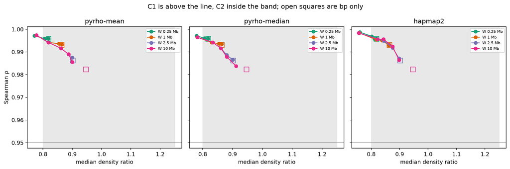

### Leads per index variant

Locus Leads over plink2’s r² 0.01 index variants, pooled over the Analyses in a band, for each map’s named point.

| map | named point | \|z\| < 38.5 | \|z\| 38.5–100 | \|z\| ≥ 100 | rows < 1k | 1k–10k | 10k–100k | rows ≥ 100k |
| --- | --- | --- | --- | --- | --- | --- | --- | --- |
| pyrho-mean | bp only / W 10 Mb | 0.19 | 0.15 | 0.18 | 0.45 | 0.32 | 0.27 | 0.11 |
| pyrho-median | bp only / W 10 Mb | 0.19 | 0.15 | 0.18 | 0.45 | 0.32 | 0.27 | 0.11 |
| hapmap2 | bp only / W 10 Mb | 0.19 | 0.15 | 0.18 | 0.45 | 0.32 | 0.27 | 0.11 |

## Per-lead diagnostics

These are #403’s diagnostics, unchanged: the per-lead rates say where Locus Leads and plink2’s index variants disagree one by one. They are not the criterion.

| map | point | Locus Leads | index variants | spurious | lost | disagreement |
| --- | --- | --- | --- | --- | --- | --- |
| pyrho-mean | 0.1 cM / W 0.25 Mb | 26,094 | 21,510 | 39.8% | 27.0% | 34.0% |
| pyrho-mean | 0.25 cM / W 0.25 Mb | 22,405 | 21,510 | 34.2% | 31.4% | 32.8% |
| pyrho-mean | 0.5 cM / W 0.25 Mb | 21,614 | 21,510 | 33.8% | 33.5% | 33.6% |
| pyrho-mean | 1 cM / W 0.25 Mb | 21,492 | 21,510 | 33.7% | 33.8% | 33.7% |
| pyrho-mean | 2.5 cM / W 0.25 Mb | 21,469 | 21,510 | 33.6% | 33.8% | 33.7% |
| pyrho-mean | bp only / W 0.25 Mb | 21,463 | 21,510 | 33.6% | 33.8% | 33.7% |
| pyrho-mean | 0.1 cM / W 1 Mb | 23,035 | 21,510 | 32.4% | 27.6% | 30.0% |
| pyrho-mean | 0.25 cM / W 1 Mb | 16,704 | 21,510 | 16.4% | 35.1% | 26.9% |
| pyrho-mean | 0.5 cM / W 1 Mb | 13,951 | 21,510 | 11.6% | 42.7% | 30.5% |
| pyrho-mean | 1 cM / W 1 Mb | 12,414 | 21,510 | 10.5% | 48.3% | 34.5% |
| pyrho-mean | 2.5 cM / W 1 Mb | 11,890 | 21,510 | 10.4% | 50.5% | 36.2% |
| pyrho-mean | bp only / W 1 Mb | 11,861 | 21,510 | 10.3% | 50.5% | 36.2% |
| pyrho-mean | 0.1 cM / W 2.5 Mb | 23,009 | 21,510 | 32.3% | 27.6% | 30.0% |
| pyrho-mean | 0.25 cM / W 2.5 Mb | 16,491 | 21,510 | 15.6% | 35.3% | 26.8% |
| pyrho-mean | 0.5 cM / W 2.5 Mb | 13,302 | 21,510 | 9.6% | 44.1% | 30.9% |
| pyrho-mean | 1 cM / W 2.5 Mb | 10,697 | 21,510 | 6.7% | 53.6% | 38.0% |
| pyrho-mean | 2.5 cM / W 2.5 Mb | 8,500 | 21,510 | 5.8% | 62.8% | 46.7% |
| pyrho-mean | bp only / W 2.5 Mb | 8,057 | 21,510 | 5.5% | 64.6% | 48.5% |
| pyrho-mean | 0.1 cM / W 10 Mb | 23,009 | 21,510 | 32.3% | 27.6% | 30.0% |
| pyrho-mean | 0.25 cM / W 10 Mb | 16,491 | 21,510 | 15.7% | 35.3% | 26.8% |
| pyrho-mean | 0.5 cM / W 10 Mb | 13,279 | 21,510 | 9.6% | 44.2% | 31.0% |
| pyrho-mean | 1 cM / W 10 Mb | 10,561 | 21,510 | 6.3% | 54.0% | 38.3% |
| pyrho-mean | 2.5 cM / W 10 Mb | 7,291 | 21,510 | 3.6% | 67.3% | 51.2% |
| pyrho-mean | bp only / W 10 Mb | 3,712 | 21,510 | 1.6% | 83.0% | 71.0% |
| pyrho-median | 0.1 cM / W 0.25 Mb | 25,713 | 21,510 | 39.1% | 27.2% | 33.7% |
| pyrho-median | 0.25 cM / W 0.25 Mb | 22,300 | 21,510 | 34.0% | 31.6% | 32.8% |
| pyrho-median | 0.5 cM / W 0.25 Mb | 21,594 | 21,510 | 33.8% | 33.5% | 33.7% |
| pyrho-median | 1 cM / W 0.25 Mb | 21,488 | 21,510 | 33.7% | 33.8% | 33.7% |
| pyrho-median | 2.5 cM / W 0.25 Mb | 21,466 | 21,510 | 33.6% | 33.8% | 33.7% |
| pyrho-median | bp only / W 0.25 Mb | 21,463 | 21,510 | 33.6% | 33.8% | 33.7% |
| pyrho-median | 0.1 cM / W 1 Mb | 22,474 | 21,510 | 31.0% | 27.9% | 29.5% |
| pyrho-median | 0.25 cM / W 1 Mb | 16,402 | 21,510 | 15.7% | 35.7% | 27.1% |
| pyrho-median | 0.5 cM / W 1 Mb | 13,785 | 21,510 | 11.6% | 43.3% | 30.9% |
| pyrho-median | 1 cM / W 1 Mb | 12,344 | 21,510 | 10.4% | 48.6% | 34.6% |
| pyrho-median | 2.5 cM / W 1 Mb | 11,882 | 21,510 | 10.4% | 50.5% | 36.2% |
| pyrho-median | bp only / W 1 Mb | 11,861 | 21,510 | 10.3% | 50.5% | 36.2% |
| pyrho-median | 0.1 cM / W 2.5 Mb | 22,443 | 21,510 | 30.9% | 27.9% | 29.5% |
| pyrho-median | 0.25 cM / W 2.5 Mb | 16,168 | 21,510 | 14.8% | 36.0% | 26.9% |
| pyrho-median | 0.5 cM / W 2.5 Mb | 13,066 | 21,510 | 9.3% | 44.9% | 31.5% |
| pyrho-median | 1 cM / W 2.5 Mb | 10,500 | 21,510 | 6.4% | 54.3% | 38.6% |
| pyrho-median | 2.5 cM / W 2.5 Mb | 8,440 | 21,510 | 5.7% | 63.0% | 46.9% |
| pyrho-median | bp only / W 2.5 Mb | 8,057 | 21,510 | 5.5% | 64.6% | 48.5% |
| pyrho-median | 0.1 cM / W 10 Mb | 22,443 | 21,510 | 30.9% | 27.9% | 29.5% |
| pyrho-median | 0.25 cM / W 10 Mb | 16,165 | 21,510 | 14.9% | 36.0% | 26.9% |
| pyrho-median | 0.5 cM / W 10 Mb | 13,037 | 21,510 | 9.2% | 45.0% | 31.5% |
| pyrho-median | 1 cM / W 10 Mb | 10,341 | 21,510 | 5.9% | 54.8% | 38.9% |
| pyrho-median | 2.5 cM / W 10 Mb | 7,097 | 21,510 | 3.5% | 68.2% | 52.1% |
| pyrho-median | bp only / W 10 Mb | 3,712 | 21,510 | 1.6% | 83.0% | 71.0% |
| hapmap2 | 0.1 cM / W 0.25 Mb | 29,307 | 21,510 | 45.4% | 25.7% | 37.1% |
| hapmap2 | 0.25 cM / W 0.25 Mb | 23,381 | 21,510 | 34.9% | 29.3% | 32.2% |
| hapmap2 | 0.5 cM / W 0.25 Mb | 21,843 | 21,510 | 33.5% | 32.5% | 33.0% |
| hapmap2 | 1 cM / W 0.25 Mb | 21,477 | 21,510 | 33.6% | 33.7% | 33.7% |
| hapmap2 | 2.5 cM / W 0.25 Mb | 21,463 | 21,510 | 33.6% | 33.8% | 33.7% |
| hapmap2 | bp only / W 0.25 Mb | 21,463 | 21,510 | 33.6% | 33.8% | 33.7% |
| hapmap2 | 0.1 cM / W 1 Mb | 26,782 | 21,510 | 40.6% | 26.0% | 34.1% |
| hapmap2 | 0.25 cM / W 1 Mb | 18,707 | 21,510 | 20.9% | 31.2% | 26.4% |
| hapmap2 | 0.5 cM / W 1 Mb | 15,339 | 21,510 | 13.0% | 37.9% | 27.5% |
| hapmap2 | 1 cM / W 1 Mb | 13,155 | 21,510 | 10.3% | 45.2% | 32.0% |
| hapmap2 | 2.5 cM / W 1 Mb | 11,935 | 21,510 | 10.3% | 50.2% | 36.0% |
| hapmap2 | bp only / W 1 Mb | 11,861 | 21,510 | 10.3% | 50.5% | 36.2% |
| hapmap2 | 0.1 cM / W 2.5 Mb | 26,717 | 21,510 | 40.4% | 26.0% | 34.0% |
| hapmap2 | 0.25 cM / W 2.5 Mb | 18,544 | 21,510 | 20.3% | 31.3% | 26.2% |
| hapmap2 | 0.5 cM / W 2.5 Mb | 14,974 | 21,510 | 11.6% | 38.4% | 27.4% |
| hapmap2 | 1 cM / W 2.5 Mb | 12,183 | 21,510 | 7.3% | 47.5% | 33.0% |
| hapmap2 | 2.5 cM / W 2.5 Mb | 9,218 | 21,510 | 5.4% | 59.5% | 43.3% |
| hapmap2 | bp only / W 2.5 Mb | 8,057 | 21,510 | 5.5% | 64.6% | 48.5% |
| hapmap2 | 0.1 cM / W 10 Mb | 26,714 | 21,510 | 40.4% | 26.0% | 34.0% |
| hapmap2 | 0.25 cM / W 10 Mb | 18,540 | 21,510 | 20.3% | 31.3% | 26.2% |
| hapmap2 | 0.5 cM / W 10 Mb | 14,943 | 21,510 | 11.4% | 38.5% | 27.4% |
| hapmap2 | 1 cM / W 10 Mb | 12,114 | 21,510 | 7.0% | 47.6% | 33.0% |
| hapmap2 | 2.5 cM / W 10 Mb | 8,739 | 21,510 | 4.3% | 61.1% | 44.7% |
| hapmap2 | bp only / W 10 Mb | 3,712 | 21,510 | 1.6% | 83.0% | 71.0% |

## Reproduce

```bash
# the two maps (their READMEs record the downloads and checksums)
pixi run -e dev python -m prototypes.locus_leads build-hapmap2-map \
    --original /data/opengwasdb/reference/genetic-map/eagle-hapmap2-hg38/original/genetic_map_hg38_withX.txt.gz \
    --output /data/opengwasdb/reference/genetic-map/eagle-hapmap2-hg38/HapMap2.tsv.gz
pixi run -e dev python -m prototypes.locus_leads build-median-map \
    --archive /data/opengwasdb/reference/genetic-map/pyrho-1kg-hg38/original/hg38_maps.tar.gz \
    --output /data/opengwasdb/reference/genetic-map/pyrho-1kg-hg38/EUR-median.tsv.gz

# one sweep per map, on #403's selection; the mean's sweep is eur_sweep.json
pixi run -e dev python -m prototypes.locus_leads sweep \
    --selection docs/benchmark-output/locus_leads/eur_sweep_selection.json \
    --stores-dir /data/opengwasdb/stores \
    --genetic-map /data/opengwasdb/reference/genetic-map/pyrho-1kg-hg38/EUR-median.tsv.gz \
    --panel /data/opengwasdb/reference/hgdp1kgp-hg38/pgen/EUR \
    --hm3 /data/opengwasdb/reference/hapmap3-hg38/hm3.grch38.alid.txt \
    --work-dir <scratch> --spikes none --threads 8 \
    --output docs/benchmark-output/locus_leads/eur_maps_pyrho_median.json
# ... and the same with --genetic-map .../eagle-hapmap2-hg38/HapMap2.tsv.gz \
#     --output docs/benchmark-output/locus_leads/eur_maps_hapmap2.json

# the shared-set check, then the three sweeps side by side
pixi run -e dev python -m prototypes.locus_leads map-shared-sets \
    --selection docs/benchmark-output/locus_leads/eur_sweep_selection.json \
    --stores-dir /data/opengwasdb/stores \
    --panel /data/opengwasdb/reference/hgdp1kgp-hg38/pgen/EUR \
    --genetic-map pyrho-mean=/data/opengwasdb/reference/genetic-map/pyrho-1kg-hg38/EUR.tsv.gz \
    --genetic-map pyrho-median=/data/opengwasdb/reference/genetic-map/pyrho-1kg-hg38/EUR-median.tsv.gz \
    --genetic-map hapmap2=/data/opengwasdb/reference/genetic-map/eagle-hapmap2-hg38/HapMap2.tsv.gz \
    --reference pyrho-mean \
    --output docs/benchmark-output/locus_leads/eur_maps_shared_set.json
pixi run -e dev python -m prototypes.locus_leads compare-maps \
    --selection docs/benchmark-output/locus_leads/eur_sweep_selection.json \
    --shared-sets docs/benchmark-output/locus_leads/eur_maps_shared_set.json \
    --genetic-map pyrho-mean=docs/benchmark-output/locus_leads/eur_sweep.json \
    --genetic-map pyrho-median=docs/benchmark-output/locus_leads/eur_maps_pyrho_median.json \
    --genetic-map hapmap2=docs/benchmark-output/locus_leads/eur_maps_hapmap2.json \
    --output docs/benchmark-output/locus_leads/eur_maps.json
pixi run -e report quarto render docs/benchmark-output/locus_leads/eur_maps.qmd
```